Skip to content

# Comparisons

`mxlpy` provides simple routines to numerically compare two models.  
For this, we use the `compare` module.

```python
import numpy as np

from example_models import get_sir, get_sird
from mxlpy import compare, make_protocol
```

import numpy as np from example_models import get_sir, get_sird from mxlpy import compare, make_protocol

## Steady-states

You can compare the steady-states of two models using the `compare_steady_states` function.

```python
ssc = compare.steady_states(get_sir(), get_sird())
```

ssc = compare.steady_states(get_sir(), get_sird())

This returns a `SteadyStateComparison` object, for which you can either access the direct comparisons

```python
ssc.variables
```

ssc.variables

|  | m1 | m2 | diff | rel_diff |
| --- | --- | --- | --- | --- |
| d | NaN | 7.121887e-02 | NaN | NaN |
| i | 8.135201e-12 | 5.272299e-12 | -2.862902e-12 | -0.351915 |
| r | 8.282880e-01 | 7.121887e-01 | -1.160993e-01 | -0.140168 |
| s | 1.717120e-01 | 2.165925e-01 | 4.488042e-02 | 0.261370 |

```python
ssc.fluxes
```

ssc.fluxes

|  | m1 | m2 | diff | rel_diff |
| --- | --- | --- | --- | --- |
| death | NaN | 5.272299e-14 | NaN | NaN |
| infection | 2.793824e-13 | 2.283880e-13 | -5.099435e-14 | -0.182525 |
| recovery | 8.135201e-13 | 5.272299e-13 | -2.862902e-13 | -0.351915 |

or plot the results

```python
_ = ssc.plot_variables()
_ = ssc.plot_fluxes()
_ = ssc.plot_all()
```

_ = ssc.plot_variables() _ = ssc.plot_fluxes() _ = ssc.plot_all()

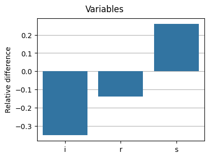

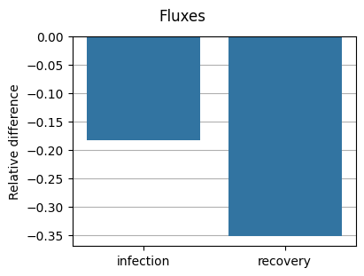

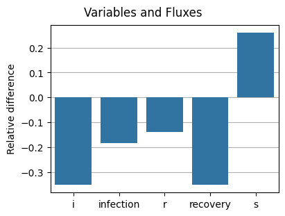

## Time courses

For comparing time courses, you can use the `compare_time_courses` function.  
This returns a `TimeCourseComparison` object, which you can directly use to plot for example the relative differences of variables or fluxes.

```python
pc = compare.time_courses(
    get_sir(),
    get_sird(),
    time_points=np.linspace(0, 100, 101),
)

_ = pc.plot_variables_relative_difference()
_ = pc.plot_fluxes_relative_difference()
```

pc = compare.time_courses( get_sir(), get_sird(), time_points=np.linspace(0, 100, 101), ) _ = pc.plot_variables_relative_difference() _ = pc.plot_fluxes_relative_difference()

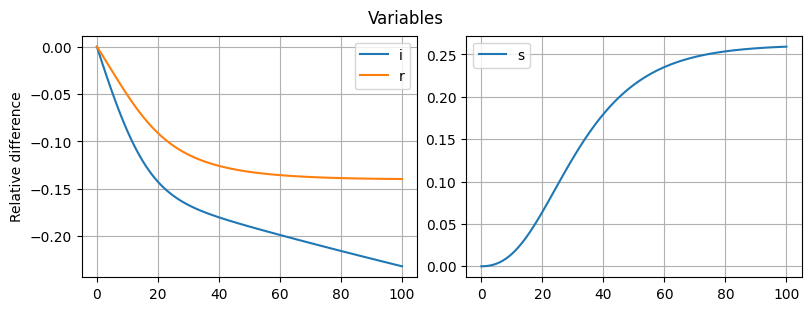

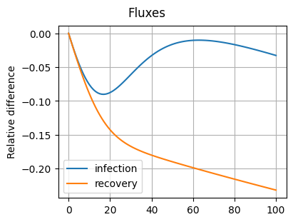

## Protocol time courses

For comparing protocol time courses, you can use the `protocol_time_courses` function.  
This returns a `ProtocolComparison` object, which you can directly use to plot for example the relative differences of variables or fluxes.

```python
pc = compare.protocol_time_courses(
    get_sir(),
    get_sird(),
    protocol=make_protocol(
        [
            (10, {"beta": 0.2}),
            (10, {"beta": 1.0}),
            (80, {"beta": 0.2}),
        ]
    ),
)

_ = pc.plot_variables_relative_difference()
```

pc = compare.protocol_time_courses( get_sir(), get_sird(), protocol=make_protocol( [ (10, {"beta": 0.2}), (10, {"beta": 1.0}), (80, {"beta": 0.2}), ] ), ) _ = pc.plot_variables_relative_difference()

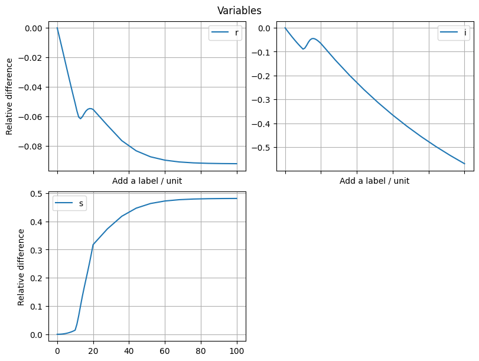

Optionally, if you want to indicate one of the protocol parameters on the plots, you can use the `shade_protocol_variable` argument

```python
_ = pc.plot_variables_relative_difference(shade_protocol_variable="beta")
_ = pc.plot_fluxes_relative_difference(shade_protocol_variable="beta")
```

_ = pc.plot_variables_relative_difference(shade_protocol_variable="beta") _ = pc.plot_fluxes_relative_difference(shade_protocol_variable="beta")

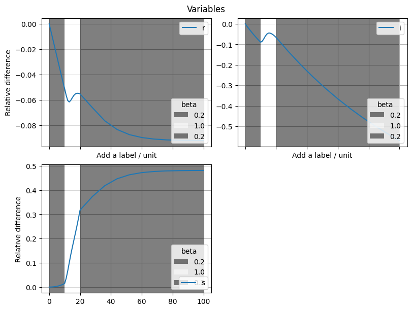

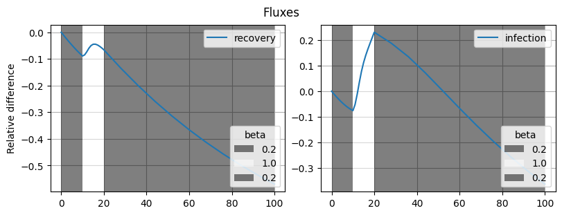